# Meta-analysis: Multi-level meta-analytic models

2022-09-30

## **Load the necessary R Packages**

```r
# Install a load of packages that we'll use. I'll show you a shortcut that I
# love to use. Try using the p_load function in the 'pacman' package. p_load
# will execute both the install.packages and library commands in one shot so
# they only need to be used once to install pacman itself.
# install.packages('pacman', repos = 'http://cran.us.r-project.org')
library(pacman)

# Install bookdown for rendering because we'll need this. While we're at it,
# lets also install /load the tidyverse
p_load(bookdown, devtools, tidyverse, ggforce, GGally, flextable, latex2exp, png,
    magick, metafor, MASS, emmeans, R.rsp)  # basically just list all the packages you want here

# Install the orchaRd package
devtools::install_github("daniel1noble/orchaRd", force = TRUE)
library(orchaRd)
```

## **Setting the scene: Meta-analysis of studies estimating the correlation between physiology and movement patterns**

Physiology is expected to drive movement, including short-term activity, exploration of unfamiliar environments, and larger scale dispersal which can influence species distributions in an environmentally sensitive manner. To test whether there is a relationship between physiology and movement pattern (categorized as activity, exploration, and dispersal movement types), [Wu & Seebacher 2022](https://doi.org/10.1038/s42003-022-03055-y) extracted correlations from the literature between common physiological traits (e.g., metabolic rate, hormone levels, body condition) and either activity, exploration, and dispersal at the individual level.

Here, we will conduct a meta-analysis of correlations taken from the literature using the Zr effect size (see below and your readings). Throughout, there will be coding tasks for you to do so that you engage with key concepts and functions that will be useful for your assignment. Below we have provided code-chunks for you. Where it says “ADD YOUR CODE HERE” you should delete this text and provide the necessary code to complete the task. There are also questions throughout. Add your answer by deleting the #“ADD YOUR ANSWER HERE” text and writing your response.

## **Task 1: Understanding Sampling Variance for Zr**

In your readings for the week you would have been introduced to various types of effect size estimates (see Table 1). There we showed you what the sampling variance actually means and how the formulas are shortcuts to estimating sampling variance. Before embarking on the meta-analysis using Zr, your first task is to understand why the formula for Zr sampling variance does in fact estimate it’s sampling variance correctly.

Recall the formula for calculating correlation-based effect size estimates taken from Table 1:

$$Zr = \frac{1}{2}log \left( \frac{1+r}{1-r}\right)$$
Here, r, is the correlation coefficient. The reason why we z-transform the correlation coefficient is because correlations range from -1 to 1. Since they are bounded, they are not necessarily normally distributed (well, arguably they are not). Z-transformation will make the distribution of correlations normal to satisfy the assumptions of meta-analytic models. Remember, these are just linear mixed / random effect models that assume the response variable (in this case an effect size) is normally distributed. Recall that the associated sampling variance calculation for Zr can be calculated as:

$$v_{Zr} = \frac{1}{N - 3}$$

Here, you will conduct a simple simulation to show $v_{Zr}$ is indeed a good approximation of its sampling error.

```r
# Lets set up the simulated experiment. We'll conduct 10000 simulations, or
# experiments, where we sample 20 individuals from a population and measure 2
# traits on those individuals that have a correlation of 0.70.
nsim = 10000
n = 20
r = 0.7
covMatrix = matrix(c(1, r, r, 1), nrow = 2, ncol = 2)

# Create an empty vector to store our simulated Zr values.
Zr <- c()

# Run our simulation. Here, we need to estimate the correlation between two
# randomly drawn traits, convert this to Zr and store it.
for (i in 1:nsim) {
    # This code will simulate two variables by sampling them from a
    # multivariate normal distribution (mvnorm). mvnorm requires the sample
    # size (number of rows in the data frame), the mean of the two variables,
    # in this case they are centered on 0 for simplicity, and the covariance
    # matrix (which here is just the correlation matrix as the variables will
    # be standardized)
    sim_r <- MASS::mvrnorm(n = n, mu = c(0, 0), Sigma = covMatrix)

    # From the data frame sim_r we now want to calculate the correlation
    cor <- cor(sim_r)[1, 2]  #'ADD YOUR CODE HERE'

    # Now, we want to convert this correlation value to Zr
    Zr_tmp <- 0.5 * log((1 + cor)/(1 - cor))  # 'ADD YOUR CODE HERE'

    # Finally, we'll merge the empty Zr vector with the value of Zr_tmp.
    Zr <- c(Zr, Zr_tmp)
}
```

In the code chunk below. Plot the sampling distribution of Zr values. Add the true mean and the sample mean to the plot as was done in the readings

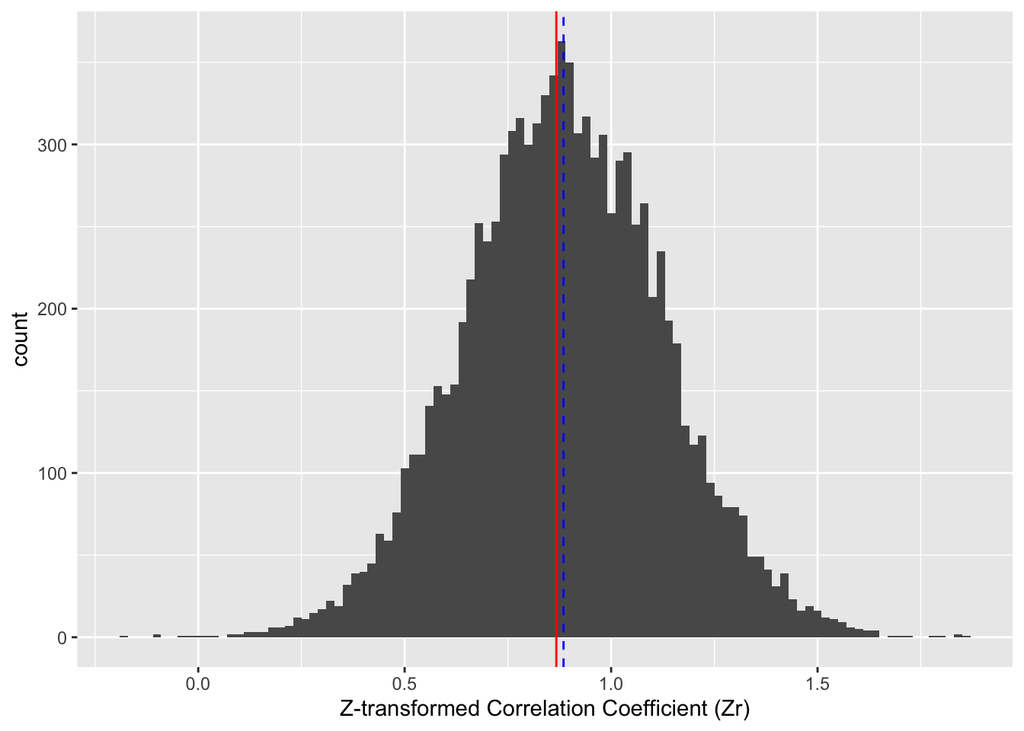

```r
#"ADD YOUR CODE HERE"
# Now lets plot the sampling distribution.
ggplot2::ggplot(tibble(Zr), aes(x = Zr)) +
  geom_histogram(binwidth = 0.02) +
  geom_vline(xintercept = 0.5*log((1 + r) / (1 - r)), col = "red") +                     # Add the true mean in red
  geom_vline(xintercept = mean(Zr), col = "blue", linetype = 2) + # Add the mean of the means
  labs(x = "Z-transformed Correlation Coefficient (Zr)")
```

```r
# We know the 'true' values so we can use them to calculate what the sampling
# variance for this specific situation should be.
sv_Zr <- 1/(n - 3)  #'ADD YOUR CODE HERE'

# We just did a simple simulation of the situation where we only calculate the
# effect size statistic, now lets see what the sampling variance is of the Zr
# sampling distribution that we calculated.
samp_dist_Zr <- var(Zr)  #'ADD YOUR CODE HERE'

# Let's create a table to contrast these a little more clearly
tab <- data.frame(Approach = c("Analytical", "Simulation"), `Sampling Variance` = c(sv_Zr,
    samp_dist_Zr), check.names = FALSE)
flextable(tab)
```

| Approach | Sampling Variance |
| --- | --- |
| Analytical | 0.0588 |
| Simulation | 0.0587 |

## **Task 2: Downloading and calculating Zr from the raw meta-analytic data**

Now that you understand Zr and it’s sampling variance better, download the data using the code chunk below. The following code illustrates how to calculate the Fisher z-transformed effect size (Zr) and sampling variance (V_Zr).

```r
# Download and clean data
zr_data <- read.csv("https://raw.githubusercontent.com/daniel1noble/meta-workshop/gh-pages/data/ind_disp_raw_data.csv") %>%
  dplyr::select(study_ID, taxa, species, trait, response, response_unit, disp_trait, disp_unit, corr_coeff, sample_size) %>%  # remove irrelevant columns for this tutorial
  mutate(residual = 1:n()) # Add this observation level variable. We'll explain later what it means.
```

Now that you have downloaded the data have a look at it, explore the data a little. The `corr_coeff` column is the correlation coefficient and the `sample_size` is the size of the sample used to estimate the correlation. The correlation coefficient itself is a unitless measure that captures both the strength and direction of relationship between two variables. The raw correlation coefficient ranges from -1 to 1. If a correlation is positive it indicates that, as the value of one variable increases so to does the value of the second variable. The magnitude of the value indicates how strong they co-vary. For example, a correlation of 1 indicates that variable 1 perfectly co-varies with variable 2.

Other important variables in the dataset are `study_ID`, which is the identifier for the study the effect size (i.e., correlation) was extracted, and `species` which identifies the species the effect size was extracted for.

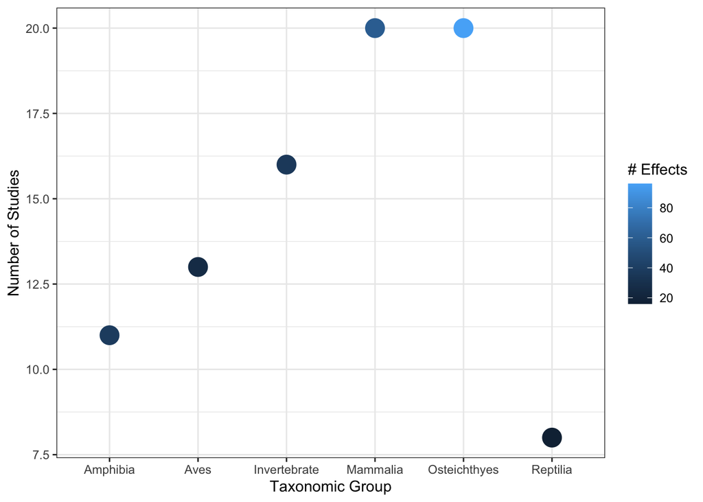

```r
#'ADD YOUR CODE HERE'
# There's a bunch of free stuff they can do here.  Studies / taxa
std_taxa <- zr_data %>%
    group_by(taxa) %>%
    summarise(stdy = length(unique(study_ID)), effects = n())
std_taxa %>%
    ggplot(aes(x = taxa, y = stdy)) + geom_point(size = 6, aes(colour = effects)) +
    labs(y = "Number of Studies", x = "Taxonomic Group", colour = "# Effects") +
    theme_bw()
```

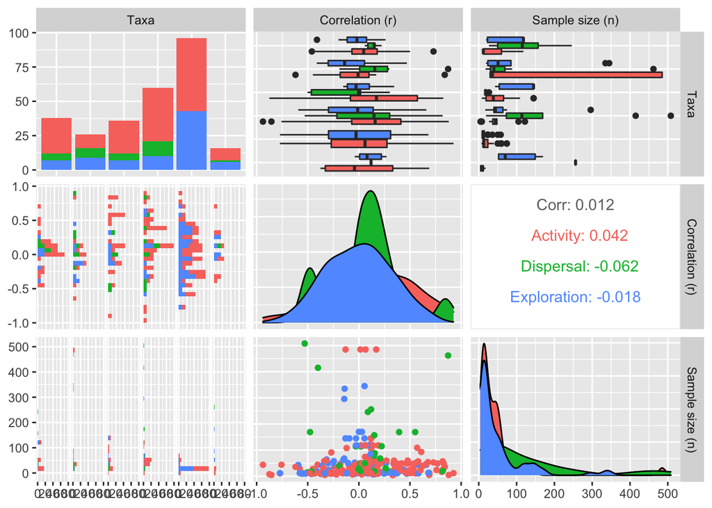

```r
ggpairs(zr_data, columns = c(2, 9:10), aes(colour = disp_trait), columnLabels = c("Taxa",
    "Correlation (r)", "Sample size (n)"))
```

We now want to convert the correlation (`corr_coeff`) to Zr instead of using the correlation (r) itself because Zr will satisfy assumptions of normality that are inherent to meta-analytic models. We can use the `escalc` function in the R package `metafor` to do that for us. Explore the help file for `escalc` and write some code to calculate Zr and its associated sampling variance. `escalc` can do this and add it to the data frame. Use the `var.names` argument to rename the effect size and sampling variance to “Zr” and “V_Zr”. In other words, set the argument to `var.names = c("Zr", "V_Zr")`.

```r
# Calculate Fisher's r-to-z transformed correlation coefficient (ZCOR) as yi =
# effect size and vi = sampling variances, where ri = raw correlation
# coefficients, and ni = sample size.
zr_data <- metafor::escalc(measure = "ZCOR", ri = corr_coeff, ni = sample_size, data = zr_data,
    var.names = c("Zr", "V_Zr"))  #'ADD YOUR CODE HERE'

zr_data %>%
    slice_head(n = 5)
```

```
##
##   study_ID         taxa             species      trait   response
## 1        1 Invertebrate Tribolium_castaneum Metabolism Routine MR
## 2        1 Invertebrate Tribolium_castaneum Metabolism Routine MR
## 3        1 Invertebrate Tribolium_castaneum Metabolism Routine MR
## 4        1 Invertebrate Tribolium_castaneum Metabolism Routine MR
## 5        1 Invertebrate Tribolium_castaneum Metabolism Routine MR
##                        response_unit  disp_trait disp_unit corr_coeff
## 1 residual CO2 production (ul_CO2_h) Exploration       PC1    -0.0277
## 2 residual CO2 production (ul_CO2_h) Exploration       PC2    -0.0936
## 3 residual CO2 production (ul_CO2_h)    Activity  counts_h     0.1170
## 4 residual CO2 production (ul_CO2_h) Exploration       PC1     0.0546
## 5 residual CO2 production (ul_CO2_h) Exploration       PC2    -0.1312
##   sample_size residual      Zr   V_Zr
## 1         145        1 -0.0277 0.0070
## 2         145        2 -0.0938 0.0070
## 3         145        3  0.1176 0.0070
## 4         145        4  0.0546 0.0070
## 5         145        5 -0.1320 0.0070
```

It’s important to note that we can convert back to the original correlation coefficient quite easily as follows:

```r
# We can easily convert back to r as follows
zr_data$r <- tanh(zr_data$Zr)

zr_data %>%
    dplyr::select(corr_coeff, r) %>%
    slice_head(n = 5)
```

```
##
##   corr_coeff       r
## 1    -0.0277 -0.0277
## 2    -0.0936 -0.0936
## 3     0.1170  0.1170
## 4     0.0546  0.0546
## 5    -0.1312 -0.1312
```

## **Task 3: Multilevel meta-analysis**

Our data is now ready for analysis! We will use the `rma.mv` function in `metafor` to fit our first multilevel meta-analysis model. You’ll recall that you seen this function in last weeks workshop. The model takes Zr as a response variable and accounts for it’s sampling variance (`V` = V_Zr). `metafor` takes the effect size sampling variance through the `V` argument. Last week, we just set this to 0 which tells the model that the effect size has no sampling variance (of course this is wrong for many statistics).

You will notice that we write out the formula for the model in the `rma.mv` function `Zr ~ 1`. This means that we want Zr as our response variable and we only want to estimate an ‘intercept’ (i.e., denoted with 1) which is the overall mean estimate for Zr, our effect size.

We are also going to estimate a random effect variance for species (i.e., `species`), between study (i.e., `study_id`) and within-study (i.e., `residual`) grouping variables to control for non-independence and understand sources driving effect size variability. These are all denoted in the `random` argument of `metafor` which takes a list of all the random effects. The random effects are denoted with a formula like structure `~1|grouping variable`, where the `grouping_variable` is the variable you want to estimate a variance for, such as `species` and/or `study_id`.

You will see below that we are also estimating a random effect at the observation / row level. This is called `residual`. Why do we do this? We do this because we want to explicitly estimate the within study variation. You can think of it as a ‘residual’ variance, which in fact is what it is, and why we’ve called it ‘residual’! `metafor` does not estimate this by default because, remember to the lecture that these models assume that all effect variation is explained by sampling variance and different true means for each study. However, because we now have a multilevel model we can start to disentangle all these courses of variance.

The full model described above can be coded as follows:

```r
# Multi-level meta-analytic model
MLMA <- metafor::rma.mv(Zr ~ 1, V = V_Zr, method = "REML", random = list(~1 | species,
    ~1 | study_ID, ~1 | residual), dfs = "contain", test = "t", data = zr_data)
MLMA
```

```
##
## Multivariate Meta-Analysis Model (k = 272; method: REML)
##
## Variance Components:
##
##             estim    sqrt  nlvls  fixed    factor
## sigma^2.1  0.0260  0.1614     79     no   species
## sigma^2.2  0.0016  0.0398     88     no  study_ID
## sigma^2.3  0.1155  0.3399    272     no  residual
##
## Test for Heterogeneity:
## Q(df = 271) = 2508.8317, p-val < .0001
##
## Model Results:
##
## estimate      se    tval  df    pval   ci.lb   ci.ub
##   0.0979  0.0347  2.8202  78  0.0061  0.0288  0.1670  **
##
## ---
## Signif. codes:  0 '***' 0.001 '**' 0.01 '*' 0.05 '.' 0.1 ' ' 1
```

In meta-analysis, the intercept has a lot of meaning because it provides us with an overall estimate of the effect from all experiments published in the literature. We would also like to know other important aspects of the model, such as:

1. the variability in effect size across studies/experiments and
2. what drives variability in effects across studies/experiments. We’ll get to that shortly.

Lets dissect out the meaning of all the meta-analytic results.

#### Overall meta-analytic mean

- We want to know what the overall meta-analytic mean effect size across the studies actually is estimated to be. We can see that from the model by extracting the intercept (labeled ‘estimate’ in the model output). Recall that the model is just an object that stores all the values for us.
- We can extract the estimate using the `coef` function, it is estimated to be 0.098, which tells us that the mean Zr value is positive, but there is a rather weak overall association between physiology and dispersal / movement when we pool across all studies.
- If we want to convert the overall meta-analytic mean back to the correlation coefficient we can use the `predict` function to help with that. We can use the `transf` argument within the function:

```r
predict(MLMA, transf = "transf.ztor")
```

[output not shown]

There are LOTS of different transformations that can be done depending on which effect size you plan on using. Get familiar with the `predict` function and the `transf` argument by looking at it’s help file (i.e., `?predict.rma`). This function will be useful for your assignment.

#### Uncertainty in the overall meta-analytic mean: 95% Confidence Intervals

- Of course, that’s just the point estimate. 95% confidence intervals are important to provide. They are stored in the MLMA object (i.e., have a look at `str(MLMA)`) as `ci.lb` and `ci.up`.
- Knowing this, we can extract the 95% confidence intervals which range from 0.029 to 0.167. In other words, 95% of the time we would expect the true mean to fall between Zr values of 0.029 to 0.167.
- In other words, if we were to repeat the experiment many times, 95% of the confidence intervals constructed would contain the true meta-analytic mean.

#### Testing the null hypthesis about whether the overall meta-analytic mean is different from 0.

- We can also see that the null hypothesis that Zr = 0 can be rejected because there is a significantly larger estimate than a correlation of 0, which we can see from the p-value being < 0.05. To be more exact, the p-value is 0.006.

## **Task 4: Understanding how much effects vary across studies – heterogeneity**

Meta-analytic mean estimates need to be interpreted in the context of how much variation in effects exist within and across studies. As such, reporting upon measures of variability, or what is referred to as ‘heterogeneity’ in meta-analysis, is essential to meta-analysis and should never be ignored (even though it often is unfortunately) (O’Dea et al. 2021; Nakagawa and Santos 2012; Borenstein 2019; Nakagawa et al. 2017; Gurevitch et al. 2018).

### Proportion of Total Heterogeneity: $I_{total}^2$

$I^2$ estimates are probably most commonly presented in the literature (Higgins et al. 2003; Higgins and Thompson 2002; Nakagawa et al. 2017; Senior et al. 2016; Borenstein 2019). Meta-analysis is unique because we know the total sampling variation in the response variable. As such, we can calculate it and ‘remove’ it from other sources of variation.

There are different forms of $I^2$ that can be calculated, but the one that describes the proportion of effect size variation after accounting for total sampling variation is $I_{total}^2$ (Nakagawa and Santos 2012). Assuming we’re using our multilevel model described above, it’s calculated as follows:

$$\begin{equation}
I^2_{total} = \frac{\sigma^2_{study} + \sigma^2_{species} + \sigma^2_{obs}}{\sigma^2_{study} + \sigma^2_{species} + \sigma^2_{obs} +\sigma^2_{m}} \
\tag{1}
\end{equation}$$

where $\sigma^2_{total} = \sigma^2_{study} + \sigma^2_{species} + \sigma^2_{obs} +\sigma^2_{m}$ is the total effect size variance and $\sigma^2_{m}$ is the ‘typical’ sampling error variance calculated as:

$$\begin{equation}
\sigma_{m}^2 = \sum w_{i}\left( k-1\right) / \left[ \left( \sum w_{i}\right)^2 + \sum w_{i}^2\right] \
\tag{2}
\end{equation}$$
From your meta-analytic model you get an estimate for all these variances, but we can use the sampling variance for each Zr effect size to calculate $\sigma^2_{m}$. To do this, we need to convert these to ‘weights’ which is simply $w_{i} = \frac{1}{v_{Zr}}$. $k$ in this equation is simply the total number of effects in the data set.

If all this looks and sounds scary, don’t panic! We have R packages and functions that can do these calculations for us.

```r
## Calculate I2
i2_vals <- orchaRd::i2_ml(MLMA)

## Make a pretty table. First, lets clean up the names of the different I2
## estimates. Lets remove I2_. It's a string, so, we can use some regular
## expressions to fix that. `gsub` is pretty useful. You put a pattern in and
## tell it what you would like to replace the text with. In this case, just
## blank will do! Then, we'll make the first letter of what is left
## capitalised.
i2 <- tibble(type = firstup(gsub("I2_", "", names(i2_vals))), I2 = i2_vals)


# You remember flextable. Now, lets make a pretty table. We can so some nice
# modifications here too.

flextable(i2) %>%
    align(part = "header", align = "center") %>%
    compose(part = "header", j = 1, value = as_paragraph(as_b("Type"))) %>%
    compose(part = "header", j = 2, value = as_paragraph(as_b("I"), as_b(as_sup("2")),
        as_b("(%)")))
```

Table 1: Total effect size hetereogneity (Total), as well as the proportion of hetereogeneity in effects resulting from Species, Study and Residual / Observational

| Type | I2(%) |
| --- | --- |
| Total | 88.110 |
| Species | 16.026 |
| Study_ID | 0.975 |
| Residual | 71.109 |

#### Interpreting $I^2$ Estimates

In the tasks below, complete the inline R code chunks to extract the relevant values.

##### First Task!

> **Interpret the meaning of $I_{Total}^2$ from the multilevel meta-analytic model**

##### First Answer!

> Overall, we have highly heterogeneous effect size data because sampling variation only contributes to 11.89% of the total variation in effects.

##### Second Task!

> **Interpret the meaning of $I_{study}^2$ from the multilevel meta-analytic model**

##### Second Answer!

> From the multilevel meta-analytic model we find that only 0.975% of the total variation in effect size estimates is the result of differences between studies.

### Quantifying heterogeneity using prediction intervals

Prediction intervals (PI) are probably the best and most intuitive way to report heterogeneity of meta-analytic results (Borenstein 2019; Noble et al. 2022; Nakagawa et al. 2021). Predictions intervals tell us how much we can expect a given effect size to vary across studies. More specifically, if we were to go out and conduct another study or experiment they tell us what the range of effect size estimates we are expected to observe 95% of the time from that new study (assuming we’re using 95% PIs) (Borenstein 2019; Noble et al. 2022; Nakagawa et al. 2021).

We can get these quite easily using the `predict` function in `metafor`:

```r
# Calculate the prediction intervals
pis <- predict(MLMA)
pis
```

```
##
##    pred     se  ci.lb  ci.ub   pi.lb  pi.ub
##  0.0979 0.0347 0.0288 0.1670 -0.6585 0.8543
```

The prediction intervals are labelled `pi.lb` (lower bound) and `pi.ub` (upper bound).

#### Interpreting Prediction Intervals

In the tasks below, complete the inline R code chunks to extract the relevant values.

##### Task!

> **If the meta-analytic mean Zr is 0.098 what would be the expected range of effect size we would expect in a future study? Are the studies consistent or inconsistent?**

##### Answer!

> Our 95% prediction intervals are wide. Effect sizes (Zr) are expected to range from -0.659 to 0.854 95% of the time with repeated experiments, suggesting a lot of inconsistency between studies.

## **Task 5: Multilevel meta-regression**

Meta-analysis often reveals substantial heterogeneity among effect estimates included in the analysis (Senior et al. 2016). While many meta-analysts are interested in ‘overall mean effects’ we need to couch these effects in context by reporting on their variability and work hard to understand what factors drive effect variability and why (Noble et al. 2022; Lajeunesse 2010).

Explaining variation in effects should probably be the main goal of every meta-analysis. Sampling variance often explains only a little amount of the total heterogeneity, so it’s important that we think hard, *a priori*, about what factors are likely to explain effect size variation.

Just like in normal linear mixed effects models, we can include fixed effects to understand how the mean effect size changes. Fixed effects in meta-analysis are called ‘moderators’ because these are biological or methodological factors that ‘moderate’ the effect or change the effect within or across studies.

From the original study aim, the first thing Wu and Seebacher (2022) were interested in is the relationship of physiology with activity, exploration and dispersal (Zr). In addition to the random effects – `residual` (effect size identity), `study_ID`(unique study identity), `species`(unique species identity), they were also interested in comparing whether the correlation (or Zr) differed depending on whether the behavioural trait of interest was activity, exploration or dispersal. That seems pretty sensible as they correlations may not really be commensurate with each other. As such, we can fit a meta-regression model, (which includes fixed effects) that includes a moderator `disp_trait` (activity, exploration, or dispersal) to explicitly test whether Zr varies across these effect types.

We can easily extend our multilevel meta-analysis model, or, intercept only model, to include fixed effects (moderators). That can be done by adjusting the formula to include the fixed effect of interest:

```r
# Multi-level meta-regression model
MLMR <- metafor::rma.mv(Zr ~ disp_trait, V = V_Zr, method = "REML", random = list(~1 |
    species, ~1 | study_ID, ~1 | residual), dfs = "contain", test = "t", data = zr_data)
MLMR
```

```
##
## Multivariate Meta-Analysis Model (k = 272; method: REML)
##
## Variance Components:
##
##             estim    sqrt  nlvls  fixed    factor
## sigma^2.1  0.0164  0.1279     79     no   species
## sigma^2.2  0.0071  0.0842     88     no  study_ID
## sigma^2.3  0.1181  0.3436    272     no  residual
##
## Test for Residual Heterogeneity:
## QE(df = 269) = 2450.9991, p-val < .0001
##
## Test of Moderators (coefficients 2:3):
## F(df1 = 2, df2 = 269) = 0.5380, p-val = 0.5846
##
## Model Results:
##
##                        estimate      se     tval   df    pval    ci.lb   ci.ub
## intrcpt                  0.1129  0.0432   2.6129   76  0.0108   0.0268  0.1990
## disp_traitDispersal      0.0056  0.0901   0.0619  269  0.9507  -0.1718  0.1829
## disp_traitExploration   -0.0650  0.0658  -0.9885  269  0.3238  -0.1945  0.0645
##
## intrcpt                *
## disp_traitDispersal
## disp_traitExploration
##
## ---
## Signif. codes:  0 '***' 0.001 '**' 0.01 '*' 0.05 '.' 0.1 ' ' 1
```

This model is very useful. You will notice that it now categorizes effect sizes based on whether they are correlations between physiology and either activity, dispersal or exploration. The `intrcpt` is the mean Zr between physiology and activity. We can see that this is 0.113.

> Question: In words, what is the null hypothesis being tested for the `intrcpt` estimate?

> Answer: We are testing the null hypothesis that the mean Zr for physiology-activity correlations is equal to 0. #“ADD YOUR ANSWER HERE”

The two additional coefficients estimated, `disp_traitDispersal` and `disp_traitExploration` are the contrasts between the mean Zr for physiology-activity and the mean Zr for both physiology-dispersal (`disp_traitDispersal`) and physiology-exploration (`disp_traitExploration`). By contrasts, we mean the difference in mean Zr.

> Question: In words, what is the null hypothesis being tested for the `disp_traitDispersal` estimate?

> Answer: We are testing the null hypothesis that the **difference** between mean Zr for physiology-activity correlations compared with the mean Zr for physiology-dispersal correlations is equal to 0. #“ADD YOUR ANSWER HERE”

Often what we do in meta-analysis is suppress the intercept so that we estimate the overall mean for each different type of Zr. We can do this easily to our model using `~ -1 + disp_trait` in the formula. Let’s try that out:

```r
# Multi-level meta-regression model
MLMR2 <- metafor::rma.mv(Zr ~ disp_trait - 1, V = V_Zr, method = "REML", random = list(~1 |
    species, ~1 | study_ID, ~1 | residual), dfs = "contain", test = "t", data = zr_data)
MLMR2
```

```
##
## Multivariate Meta-Analysis Model (k = 272; method: REML)
##
## Variance Components:
##
##             estim    sqrt  nlvls  fixed    factor
## sigma^2.1  0.0164  0.1279     79     no   species
## sigma^2.2  0.0071  0.0842     88     no  study_ID
## sigma^2.3  0.1181  0.3436    272     no  residual
##
## Test for Residual Heterogeneity:
## QE(df = 269) = 2450.9991, p-val < .0001
##
## Test of Moderators (coefficients 1:3):
## F(df1 = 3, df2 = 269) = 3.0408, p-val = 0.0295
##
## Model Results:
##
##                        estimate      se    tval   df    pval    ci.lb   ci.ub
## disp_traitActivity       0.1129  0.0432  2.6129  269  0.0095   0.0278  0.1980
## disp_traitDispersal      0.1185  0.0796  1.4882  269  0.1379  -0.0383  0.2752
## disp_traitExploration    0.0479  0.0569  0.8421  269  0.4005  -0.0641  0.1599
##
## disp_traitActivity     **
## disp_traitDispersal
## disp_traitExploration
##
## ---
## Signif. codes:  0 '***' 0.001 '**' 0.01 '*' 0.05 '.' 0.1 ' ' 1
```

Wow, there are some big changes here! Why? Well, because we are now estimating the mean Zr in each category (not the contrasts) and so the null hypotheses being tested are different.

- First, we see that the `intrcpt` goes away and is replaced by `disp_traitActivity`. It is no surprise that the value of this estimate remains the same at 0.113. That’s because, well, it’s the same thing, the mean Zr for the effects in the `disp_traitActivity` category.
- Second, you’ll notice that the `disp_traitDispersal` and `disp_traitExploration` coefficients totally change. That’s because these are no longer contrasts, but they are the mean Zr in each of those levels in `disp_trait`. You will notice here that only the mean Zr for physiology-activity correlations are significantly different from 0.

There are some nice graphical approaches that capture the meta-analytic model results. We can use “orchard” plots which are modifications to what are called forest plots. We can do this with the `orchaRd` R package:

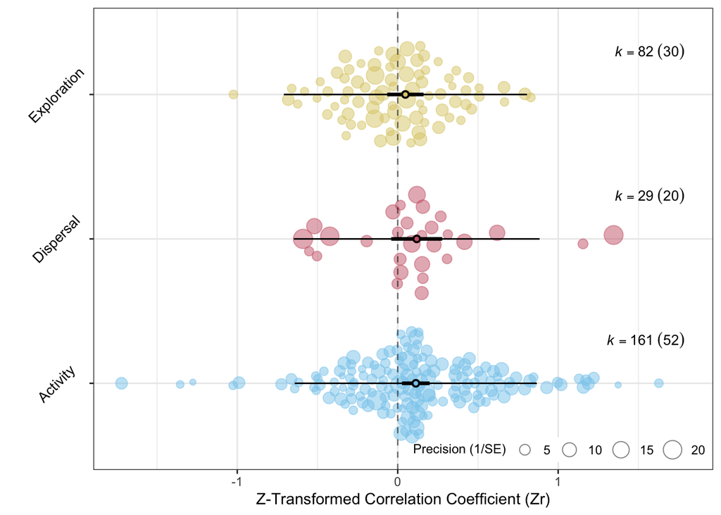

```r
# Make an orchard plot using the model object
orchaRd::orchard_plot(MLMR, mod = "disp_trait", group = "study_ID", data = zr_data,
    xlab = "Z-Transformed Correlation Coefficient (Zr)", angle = 45)
```

## **Rendering**

> Now that you have completed the Rmarkdown document try rendering it as an HTML. Does it work? If not, why not? If it’s working one code chunk at a time try to clear your working directory (i.e., `rm(list = ls()`) and re-run each code chunk.

## **References**

Borenstein, Micheal. 2019. “Heterogenity in Meta-Analysis.” In, edited by Harris Cooper, Larry V. Hedges, and Jeffrey C. Valentine, 3rd Edition, 454–66. New York: Russell Sage Foundation.

Gurevitch, Jessica, Julia Koricheva, Shinichi Nakagawa, and Gavin Stewart. 2018. “Meta-Analysis and the Science of Research Synthesis.” *Nature* 555: 176–82.

Higgins, J. P. T., and S. G. Thompson. 2002. “Quantifying Heterogeneity in a Meta-Analysis.” *Statistics in Medicine* 21: 1539–58.

Higgins, J. P. T., S. G. Thompson, J. J. Deeks, and D. G. Altman. 2003. “Measuring Inconsistency in Meta-Analyses.” *British Medical Journal* 327: 557–60.

Lajeunesse, M. J. 2010. “Achieving Synthesis with Meta-Analysis by Combining and Comparing All Available Studies.” *Ecology* 91 (9): 2561–64.

Nakagawa, Shinichi, Malgorzata Lagisz, Rose E. O’Dea, Joanna Rutkowska, Yefeng Yang, Daniel W. A. Noble, and Alistair M. Senior. 2021. “The Orchard Plot: Cultivating Forest Plots for Use in Ecology, Evolution and Beyond.” *Research Synthesis Methods* 12: 4–12.

Nakagawa, Shinichi, Daniel W. A. Noble, Alistair M. Senior, and Malgorzata Lagisz. 2017. “Meta-Evaluation of Meta-Analysis: Ten Appraisal Questions for Biologists.” *BMC Biology*, 15–18, DOI 10.1186/s12915-017-0357-7.

Nakagawa, Shinichi, and Eduardo SA Santos. 2012. “Methodological Issues and Advances in Biological Meta-Analysis.” *Evolutionary Ecology* 26 (5): 1253–74.

Noble, Daniel W. A., Patrice Pottier, Malgorzata Lagisz, Samantha Burke, Szymon M. Drobniak, Rose E. O’Dea, and Shinichi Nakagawa. 2022. “Meta-Analytic Approaches and Effect Sizes to Account for ‘Nuisance Heterogeneity’ in Comparative Physiology.” *Journal of Experimental Biology* 225: jeb243225.

O’Dea, Rose E., Malgorzata Lagisz, Michael D. Jennions, Julia Koricheva, Daniel W. A. Noble, Timothy H. Parker, Jessica Gurevitch, et al. 2021. “Preferred Reporting Items for Systematic Reviews and Meta-Analyses in Ecology and Evolutionary Biology: A PRISMA Extension.” *Biological Reviews* doi: 10.1111/brv.12721.

Pappalardo, Paula, Kiona Ogle, Elizabeth A. Hamman, Bruce A. Hungate, and Craig W. Osenberg. 2020. “Comparing Traditional and Bayesian Approaches to Ecological Meta-Analysis.” *Methods in Ecology and Evolution* 11: 1286–95.

Rosenberg, M. S. 2013. “Moment and Least Squares Based Approaches to Meta-Analytic Inference.” *In: Handbook of Meta-Analysis in Ecology and Evolution (Eds J. Koricheva, J. Gurevitch & K. Mengersen), Princeton University Press, Princeton, New Jersey.*, pp 108–124.

Senior, A. M., C. E. Grueber, T. Kamiya, M. Lagisz, K. O’dwyer, E. S. A. Santos, and Shinichi Nakagawa. 2016. “Heterogeneity in Ecological and Evolutionary Meta‐analyses: Its Magnitude and Implications.” *Ecology* 97 (12): 3293–99.

Wu, Nicholas C., and Frank Seebacher. 2022. “Physiology Can Predict Animal Activity, Exploration, and Dispersal.” *Communications Biology* 5: 1–11.